# Dice Check

Duane Stanton

05-Sep-2024

```r
knitr::opts_chunk$set(echo = TRUE)
```

```r
pkgs <- c("pwr", "dplyr", "ggplot2", "tidyr", "knitr", "kableExtra", "shiny")
for (i in seq_along(pkgs)) {library(pkgs[i], character.only = TRUE)}
# DnD character generation option: roll 4d6, take the top 3
# simulating to check distribution of that approach

# function to simulate dice rolls ==============================================
# inputs:
# - counts: vector for number of rolls
# - sides: vector of sides per die (aligned with counts)
# - seed: number to set random number generator seed for replication
#     default (NULL) sets no RNG seed
# - drop.lowest.n: vector to specify if dropping the lowest 'n' results
#     default (NULL) will drop none for any roll
#     a single number will apply that number to any roll
#     a vector of
# output:
# - list with 1 entry per roll set; each entry has the final rolls
#     (excluding any lowest dropped rolls if specified) and sum of the set
#     the final list entry is the sum across all roll sets
roll <- function(counts, sides, seed = NULL, drop.lowest.n = NULL) {
  if (length(counts) != length(sides)) {stop("counts and sides lengths don't match")}
  if (!all(sides %in% c(4, 6, 8, 10, 100, 12, 20))) {
    stop("sides can only contain 4, 6, 8, 10, 100 (%), 12, 20")}
  set.seed(seed)
  pct_idx <- sides == 100

  if (is.null(drop.lowest.n)){d.l.n <- rep(0, length(counts))
  } else {
    if (any(drop.lowest.n >= counts)) {stop("drop.lowest.n must be at most counts - 1")}
    if (length(drop.lowest.n) == 1L) {d.l.n <- rep(drop.lowest.n, length(counts))
    } else {
      if (length(drop.lowest.n) != length(counts)) {
        stop("drop.lowest.n must be one of: same length as counts, a single number, or NULL")
      }
      d.l.n <- drop.lowest.n
      }
  }

  # check feasibility of dropping lowest 'n' rolls in each case
  if (any(d.l.n < 0)) {stop("drop.lowest.n cannot be negative")}

  roll_set <-
    lapply(1:length(sides), function(i) {
      if (pct_idx[i]) {
        ones <- sample(0:9, size = counts[i], replace = TRUE)
        tens <- sample(0:9 * 10, size = counts[i], replace = TRUE)
        rslt <- tens + ones
        rslt[rslt == 0] <- 100

        if (d.l.n[i] > 0) {rslt <- (rslt[order(rslt)])[-c(1:d.l.n[i])]}
        rslt <- list("rolls" = rslt, "sum" = sum(rslt))
        rslt
      } else {
        rslt <- sample(1:sides[i], size = counts[i], replace = TRUE)
        if (d.l.n[i] > 0) {rslt <- (rslt[order(rslt)])[-c(1:d.l.n[i])]}
        rslt <- list("rolls" = rslt, "sum" = sum(rslt))
        rslt
        }
      })

  names(roll_set) <- paste0(counts, "d", ifelse(pct_idx, "%", sides))
  sums <-
    vapply(seq_along(roll_set), function(i){roll_set[[i]]$sum}, numeric(1L))

  roll_set[[length(roll_set) + 1]] <- c("ovr total" = sum(sums))

  roll_set
}

# just curious: impact of 3d4 minus 2 versus 1d10 (same min/max)
# data.frame(setup = c("3d4 - 2 vs. 1d10"),
#            sim_seed = 1:1e4) %>%
#   mutate(
#     results = lapply(1:nrow(.), function(i){
#       roll(counts = c(3, 1), sides = c(4, 10), seed = .$sim_seed[i])
#     })
#   ) %>%
#   mutate(
#     res_3d4mns2 = vapply(1:nrow(.), function(i) {
#       .$results[[i]]$`3d4`$sum - 2}, numeric(1L)),
#     res_1d10 = vapply(1:nrow(.), function(i) {
#       .$results[[i]]$`1d10`$sum}, numeric(1L)),
#   ) %>%
#   pivot_longer(cols = starts_with("res_"),
#                names_to = "roll", names_prefix = "res_",
#                values_to = "result") %>%
#   ggplot(aes(x = result, color = roll)) +
#   geom_density() +
#   scale_x_continuous(breaks = 1:10, minor_breaks = FALSE)

# unsurprising - 3d4 - 2 concentrates results closer to center of results range
# (esp. 4-7); 1d10 is more 'swingy'
```

# 1 Analysis Plan

- Chi-square Goodness of Fit (GoF) Test
- Bayesian multinomial modeling

# 2 Dice set notes

- ‘white’: Chessex ‘speckled arctic camo’ 7-die set (CHX 25311); mostly white with grey flecks and black numbering, giving it a ‘granite’ appearance
  - urea
- ‘grey’: Chessex ‘speckled granite’ 7-die set (CHX 25320); white ‘core’ composition with extensive darker grey flecks and some lighter grey flecks, and ‘blood-red’ numbering
  - urea
  - *retired from use due to the mottled grey/dark red color scheme being hard to read unless under very bright light; re-inking while trying to keep reddish numbering didn’t help*
- ‘black’: Chessex ‘speckled urban camo’ 7-die set (CHX 25328); dark grey ‘core’ composition with extensive black flecks and yellow numbering
  - urea
- ‘green’: FanRoll ‘recycled rainbow’ 7-die set; white ‘core’ composition with various-colored flecks throughout and green numbering
  - resin
- ‘teal1’ and ‘teal2’: Gravity Dice individual d20s; teal with silver numbering (same coloring for each; unfortunately before rolling I did not note this, but one has the 15 at the bottom of its facet ‘triangle’ - otherwise they appear identical; based on subsequent test rolls, I believe the ‘15 label at bottom’ die is ‘teal1’)
  - 6061 aluminum
- ‘mushroom’: [Etsy-gifted] individual d20; clear with embedded moss, lavender, and a small mushroom and gold numbering
  - resin
- ‘aubergine’: Die Hard Dice ‘Rerolls’ recycled plastic 7-die set; dark purple (d8 and d20 are closer to ‘plum’, being lighter) with embedded glitter and white numbering
  - acrylic
- ‘ocean’: TheWizardsVault ‘ocean opal’ 7-die set; translucent cyan with gold foil inclusion and gold numbering
  - resin
- ‘ice’: FeverDream Dice ‘ice queen’ 7-die set; opaque white with blue/green microglitter and gold foil inclusion and pastel light blue numbering
  - resin, sharp-edged (all others thus far are round-edged)
  - unique among sets thus far, the d4 is a bipyramid (‘shard’) rather than a tetrahedron

# 3 Rolling Surface

- Initial rolls (white, grey, black, most green rolls): FanRoll velvet dice tray with leather backing (‘rainbow watercolor’); 10” x 10” dimensions, moderate padding
- Later rolls (rest of green, teal[1/2], mushroom, aubergine, ocean, ice rolls): GameGenic Tokens’ Lair magnetic dice tray; 6.5” x 3.75” dimensions, less padding
  - Starting with the ‘ice’ dice, a uniform layer of cork was added to the tray to provide better cushioning for the sharp-edge dice

# 4 Power Analysis to Determine Sample Size to Vet Dice

```r
sets <- c("white", "grey", "black", "green", "teal1", "teal2", "mushroom", "aubergine", "ocean", "ice")
dice <- paste0("d", c(4, 6, 8, 10, "%", 12, 20))
alpha <- 0.05 # P(reject null[fair die] | actually fair die)
pwr <- 0.80 # P(don't reject null | alt [stated bias exists] is true)

side_levels <- c(0:20, seq(30, 90, by = 10))

# null hypothesis: equal probability for each side
# alternative hypothesis: one side is 'preferred' (100 * alt_pref)% more
#  (by dice structure, that means opposite side dice is 'disliked' by same %)
#  (I'm assuming this holds true for d4 too)
alt_pref <- 0.33333

dice_setup <-
  data.frame(
    set = rep(sets, each = length(dice)),
    die = rep(dice, times = length(sets))
    ) %>%
  # only d20 for teal1/teal2/mushroom 'set's
  filter(!((grepl("teal", set) | grepl("mushroom", set)) &
           die %in% paste0("d", c(4, 6, 8, 10, "%", 12)))) %>%
  mutate(
    sides_char = ifelse(grepl("\\%", die), 10, sub("d", "", die)),
    sides = as.numeric(sides_char)
  ) %>%
  select(-sides_char) %>%
  # note: need separate mutate() calls when the previous mutate-created
  #       content is needed to create subsequent multi-step entry
  mutate(
    null = lapply(1:nrow(.), function(i) {
      rep(1 / .$sides[i], times = .$sides[i])
    }),
    alt = lapply(1:nrow(.), function(i) {
      eq_prob <- 1 / .$sides[i]
      prefr <- (1 + alt_pref) * eq_prob
      dislk <- (1 - alt_pref) * eq_prob
      rest <- (1 - (prefr + dislk)) / (.$sides[i] - 2)

      c(prefr, dislk, rep(rest, .$sides[i] - 2))
    })
  ) %>%
  mutate(
    effect_size = vapply(1:nrow(.), function(i) {
      ES.w1(P0 = .$null[[i]], P1 = .$alt[[i]])
    }, numeric(1L))
  ) %>%
  mutate(
    sample_size = vapply(1:nrow(.), function(i) {
      N_ <-
      pwr.chisq.test(w = .$effect_size[i],
                     N = NULL,
                     df = .$sides[i] - 1,
                     sig.level = alpha,
                     power = pwr)$N

     ceiling(N_) # round up
    }, numeric(1L))
  )
```

# 5 Checking Dice

## 5.1 Data Collection

Notes on data collection:

- Rolls must land in the dice tray; any roll outside it will be rejected (this includes rolls hitting the edge of the dice tray and landing outside the tray, rolls landing on the dice tray but then bouncing out, and rolls landing outside the dice tray but then bouncing in; rolls hitting the dice tray side but no other object and landing inside the tray will be included)
- Rolls must be spun in the air; any roll (subjectively) deemed to have been insufficiently ‘spun’ will be rejected (i.e. it felt like I basically just dropped the dice instead of spinning it in the air)
- Dice are rolled one at a time; each result is recorded before picking up the die to conduct the next roll
- If the die doesn’t come to rest fully on one face (i.e. one edge of the die is resting against the side of the dice tray), the die must be (subjectively) deemed completely unambiguous as to which side *would be* facing up if the tray side were not there for the roll to be recorded
- If the die is rotated while picking it up and before the roll result is noted, the die should be rolled twice without recording the results before resuming recording of roll results (to potentially reduce the risk of bias in the recorded result, should one roll have an association with the prior one)
- The roll technique is described below:
- The die starts sitting upright in the open right hand, only slightly cupped with the die generally resting around the base of the middle and ring fingers
- The roll is an upward and ‘counterclockwise’ (wrist rotates the pinky to the right) twist, allowing the die to roll from the hand; generally this means the die rolls off the pinky, or occasionally the ring finger
- After each roll is recorded, the die is simply picked up and re-rolled; no deliberate care is made to randomize or control the up-facing side of the die (generally it seems to differ from the previous roll’s result due to the picking up action)

```r
# quick plotting function
plot_result <- function(df, fill_color = "dodgerblue2") {
  set_die <- deparse(substitute(df)) # store df name as text
  set_ <- sub("^([a-z]+)_d[0-9|%]{1,2}_df$", "\\1", set_die)
  die_ <- sub("^[a-z]+_(d[0-9|%]{1,2})_df$", "\\1", set_die)

  avg_count <- (1 / length(unique(df$result))) * nrow(df)

  ggplot(df, aes(x = result)) +
    geom_vline(xintercept = mean(df$result), linetype = "solid") +
    geom_hline(yintercept = avg_count, linetype = "solid") +
    geom_bar(fill = fill_color, color = "black") +
    labs(title = paste("Plot of", set_, die_, "results"),
         subtitle = paste("n = ", nrow(df)),
         caption = paste0("Horizontal line indicates expected count (",
                          sprintf("%.1f", avg_count),
                          "); Vertical line indicates mean value (",
                          sprintf("%.1f", mean(df$result)),")")) +
    scale_x_continuous(breaks = unique(df$result)) +
    theme_bw()
}


set_fill_map <-
  c("white" = "ivory3", "grey" = "grey40",
    "black" = "grey10", "green" = "green4",
    "teal1" = "darkcyan", "teal2" = "steelblue4",
    "mushroom" = "gold3", "aubergine" = "#614051",
    "ocean" = "cyan2", "ice" = "powderblue")
```

### 5.1.1 White Dice

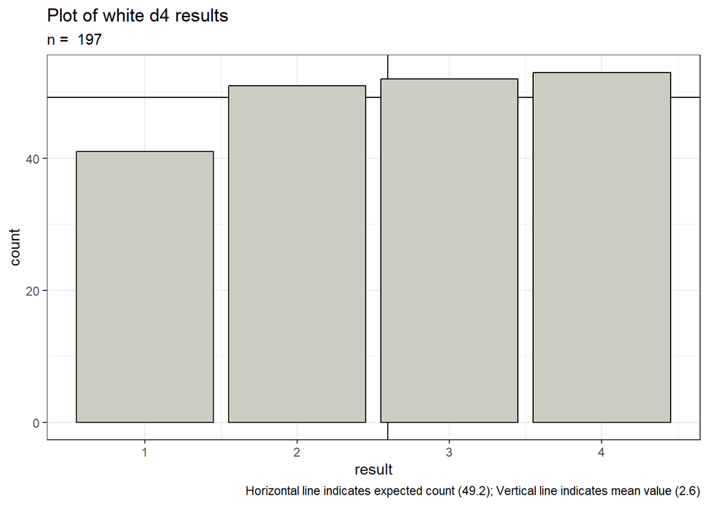

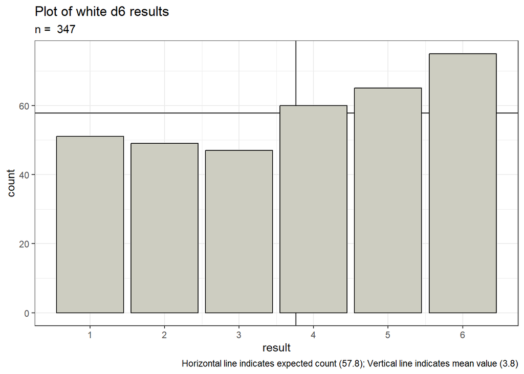

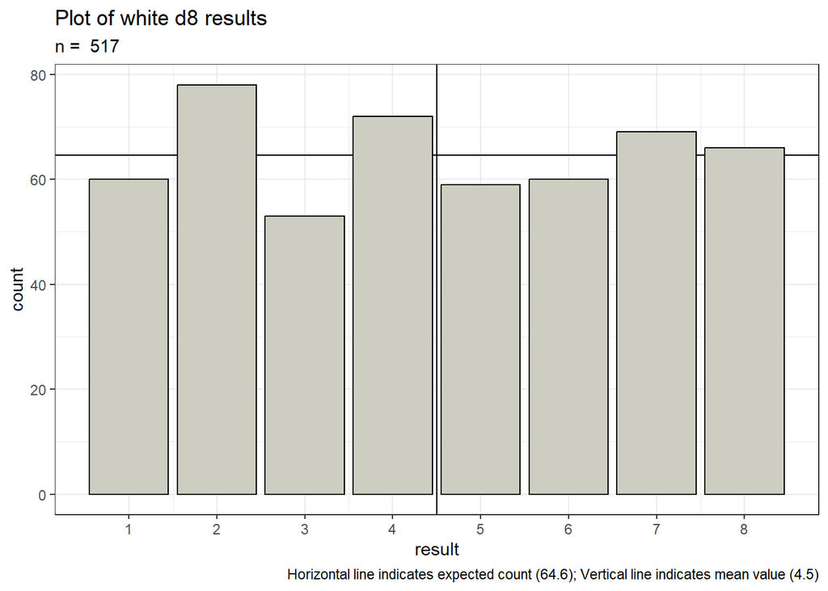

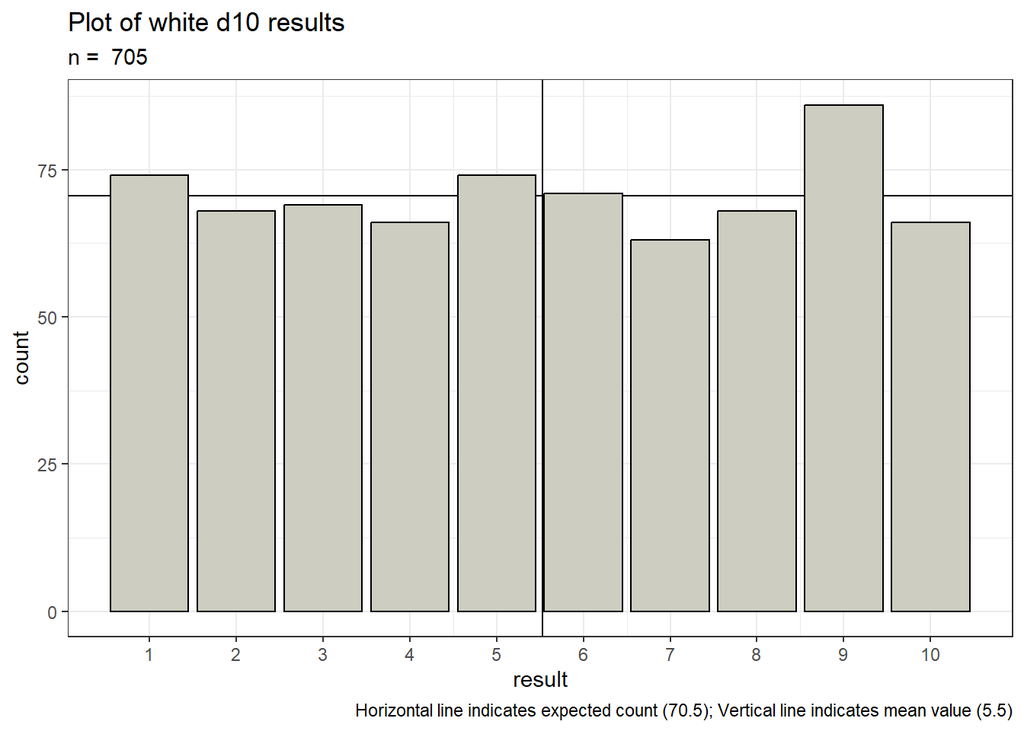

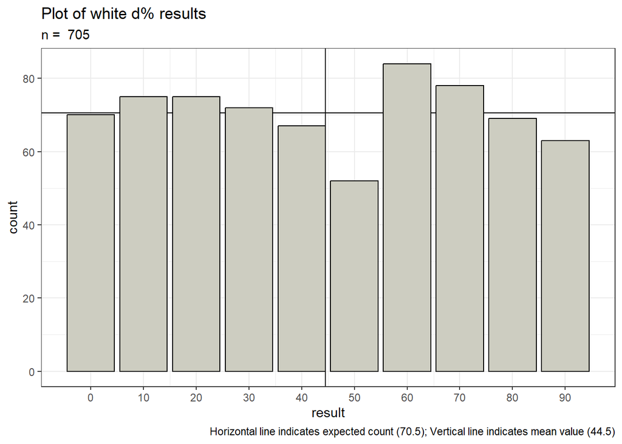

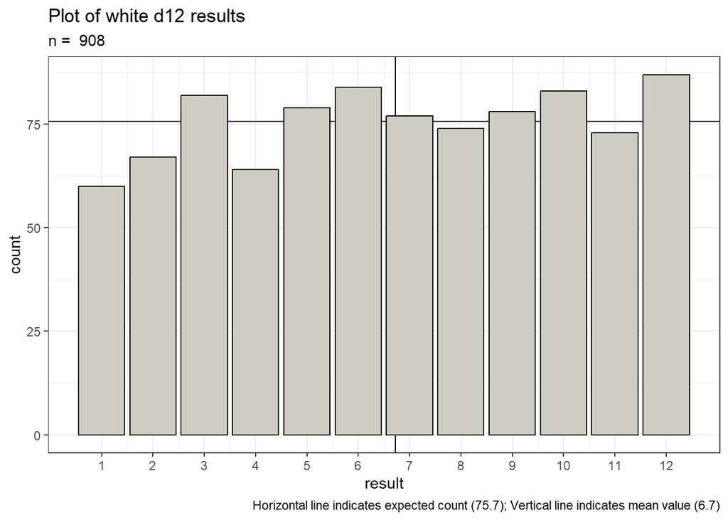

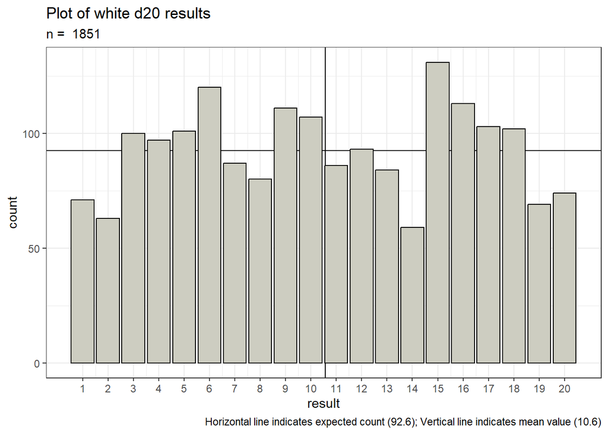

### 5.1.2 Grey Dice

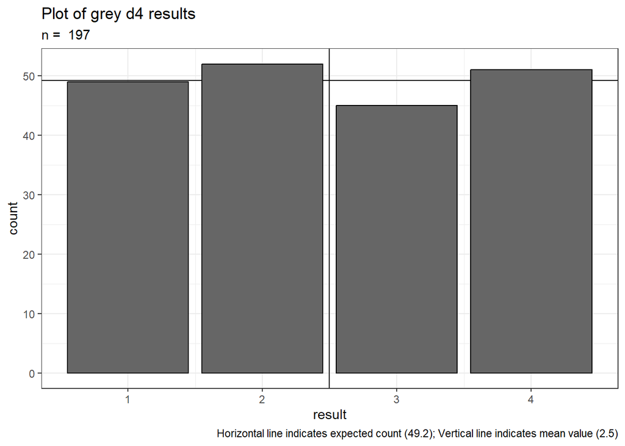

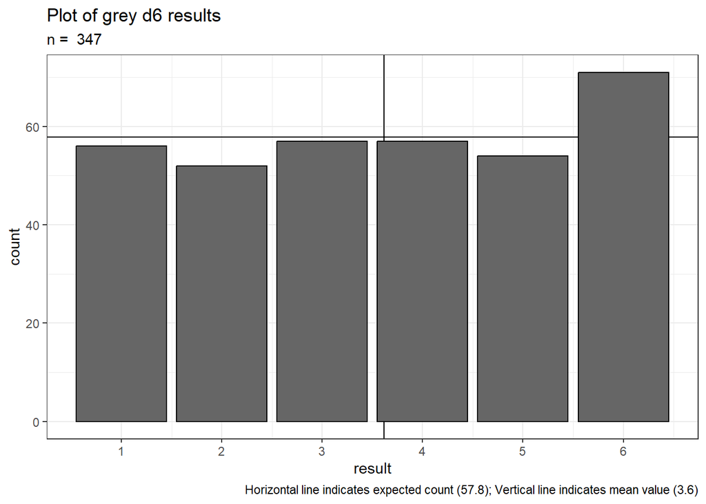

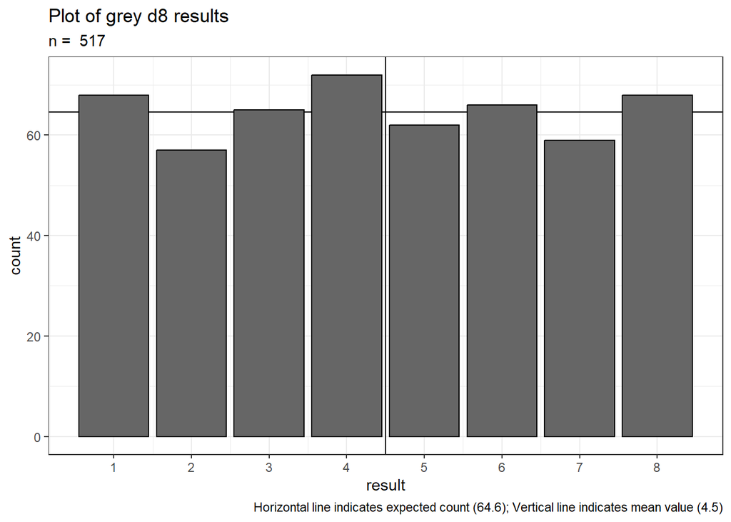

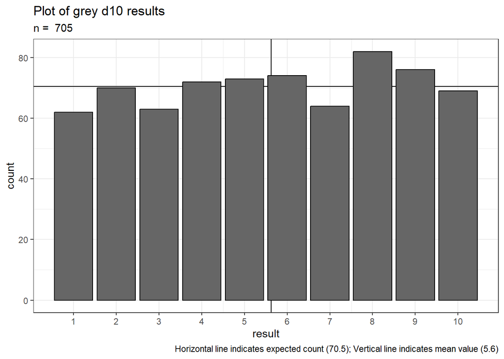

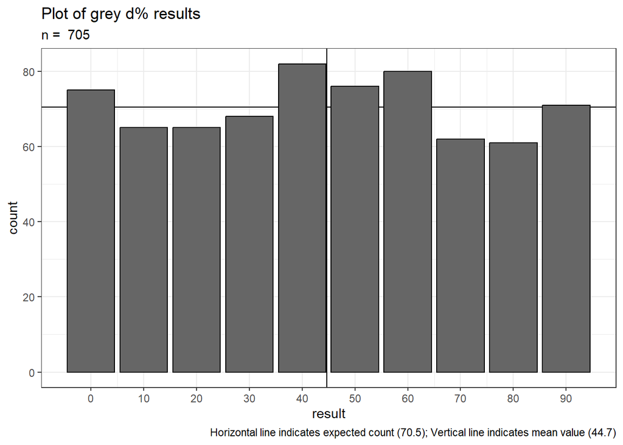

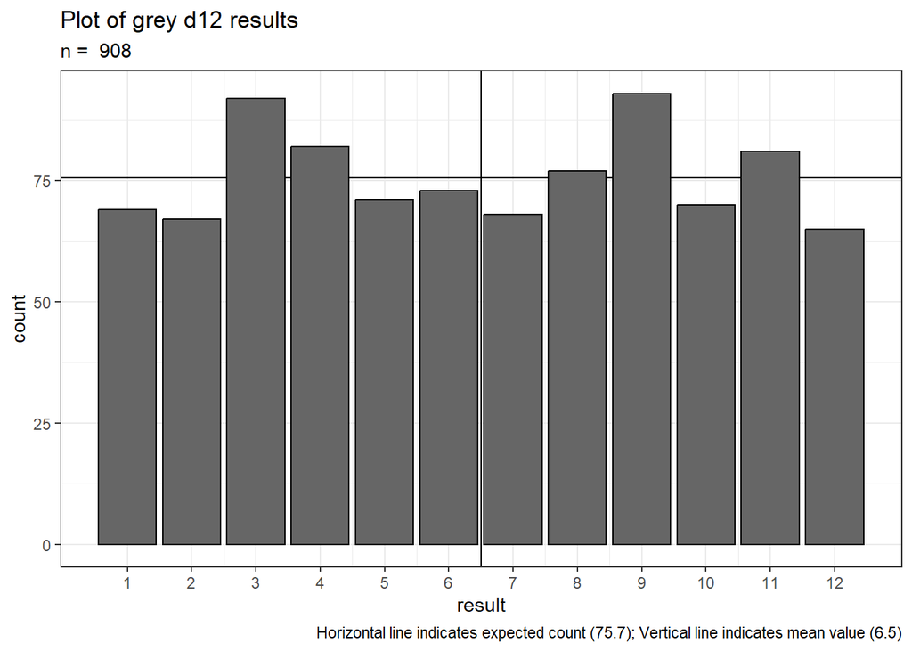

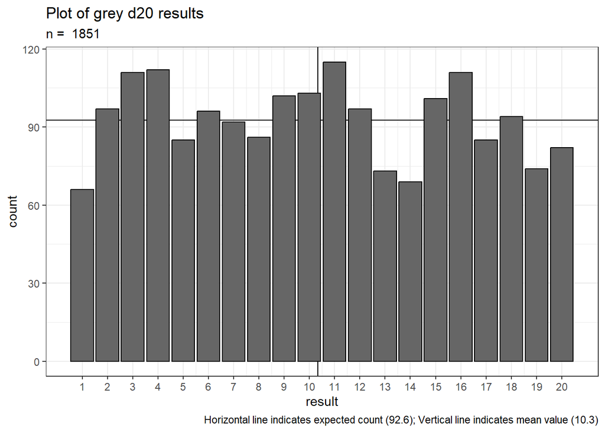

### 5.1.3 Black Dice

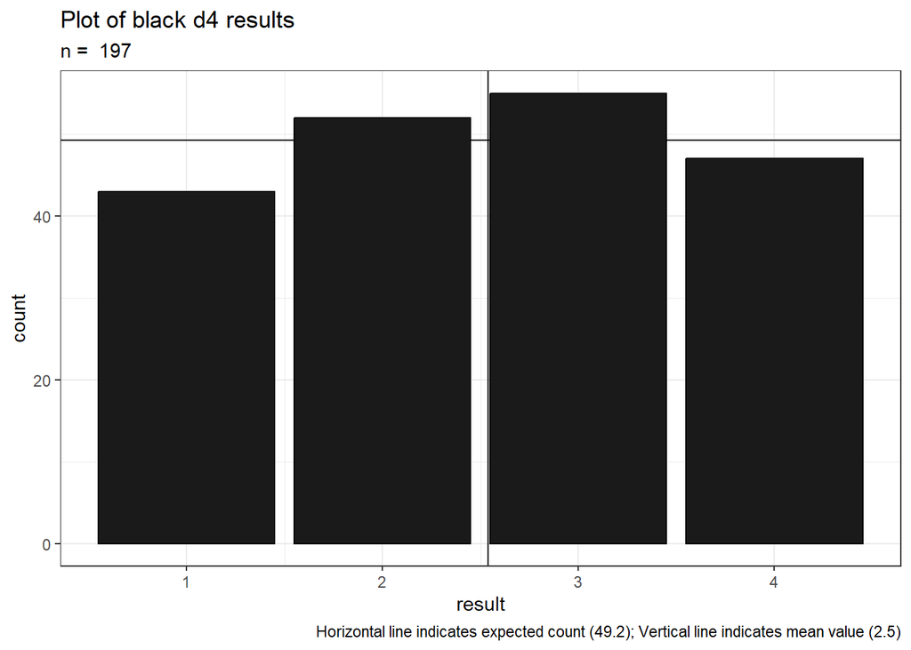

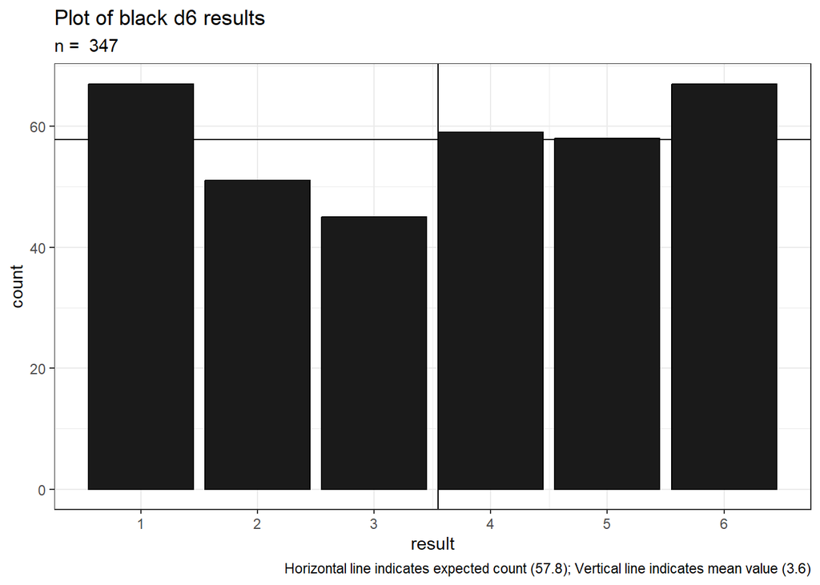

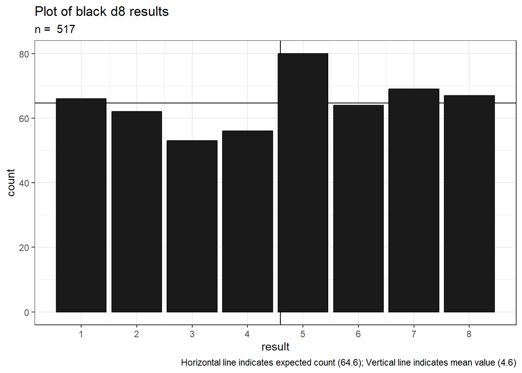

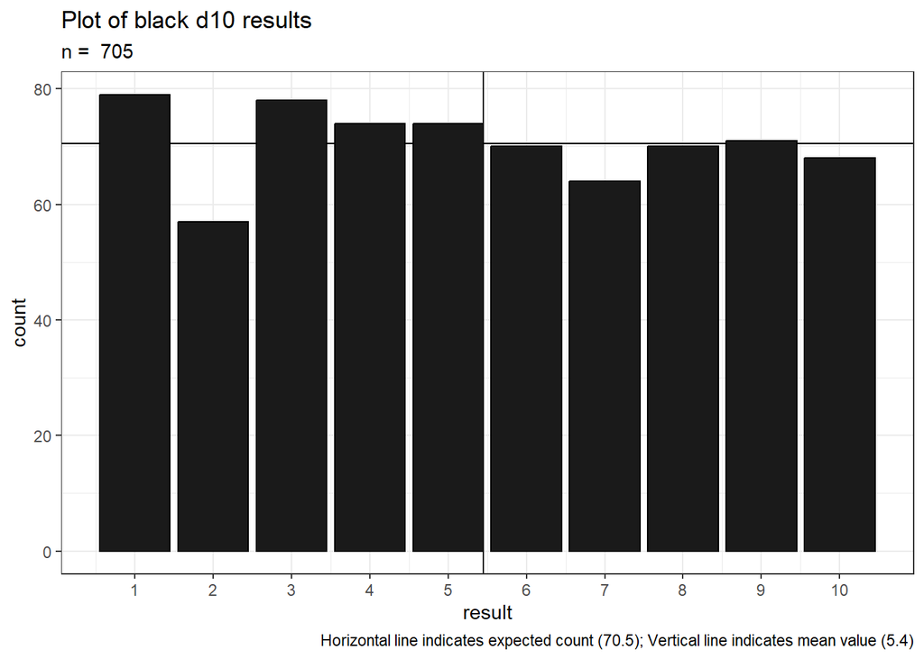

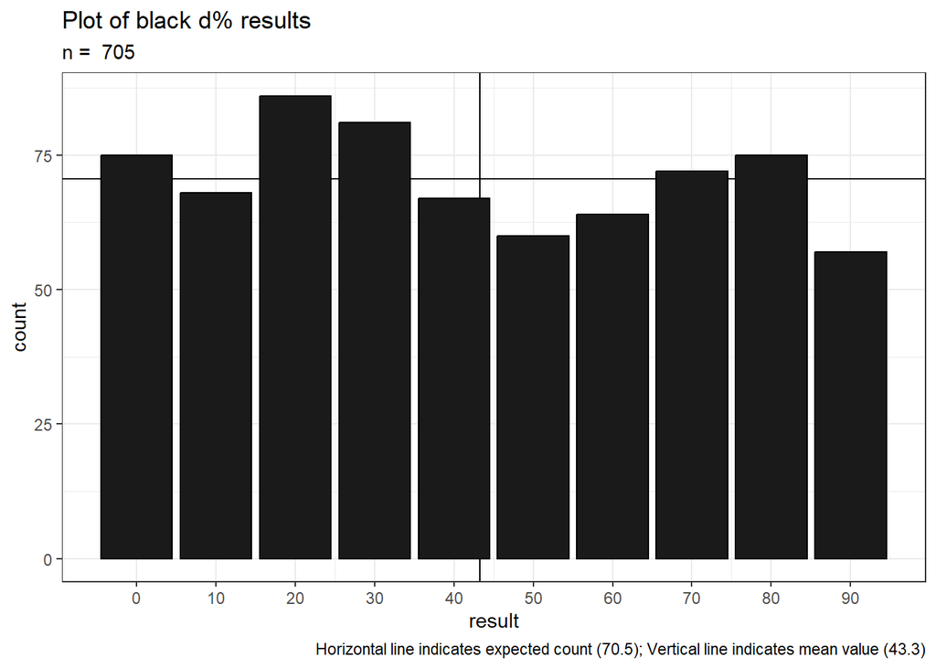

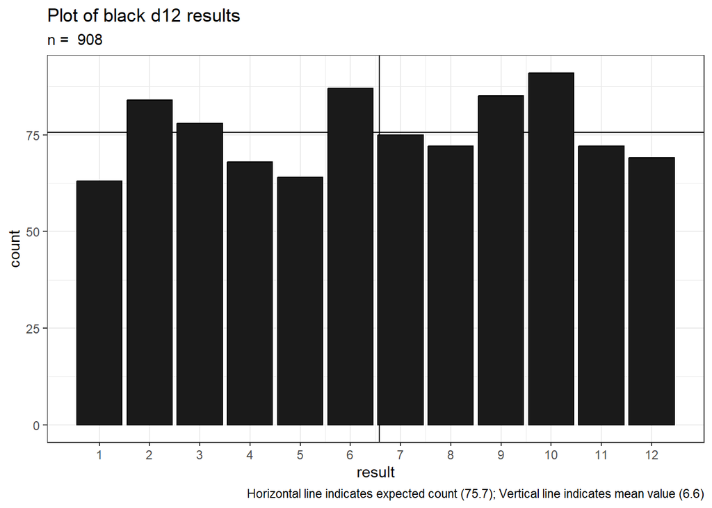

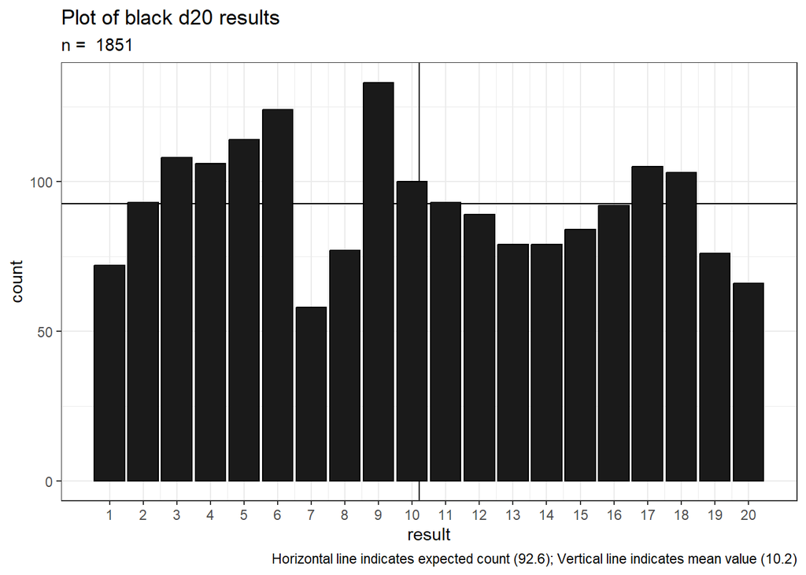

### 5.1.4 Green Dice

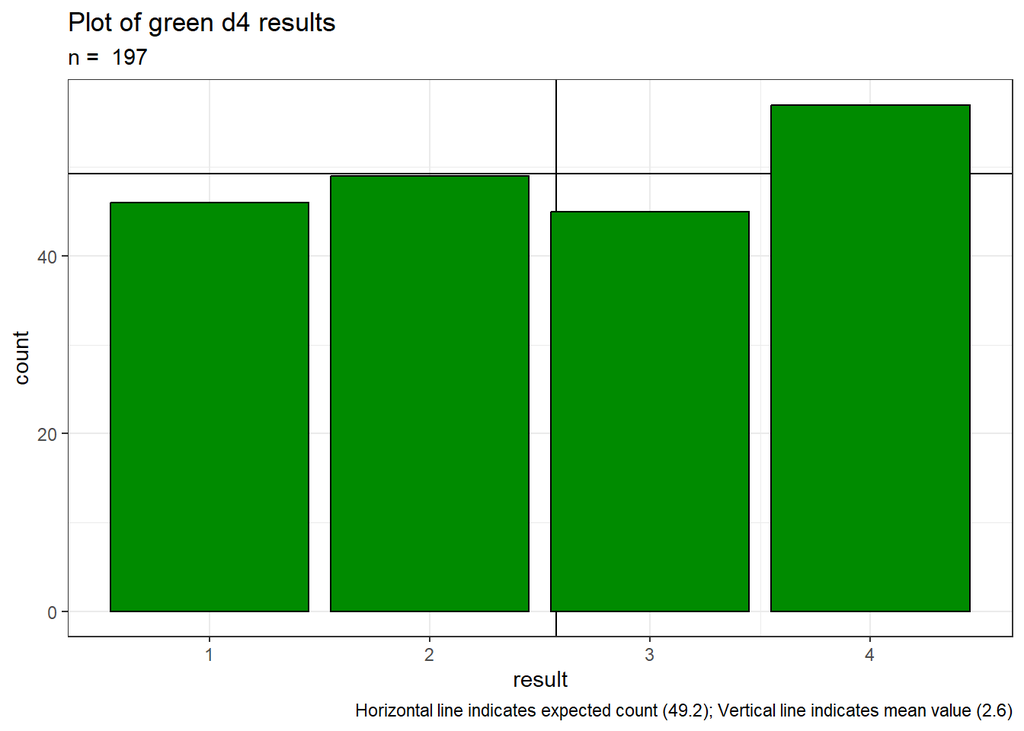

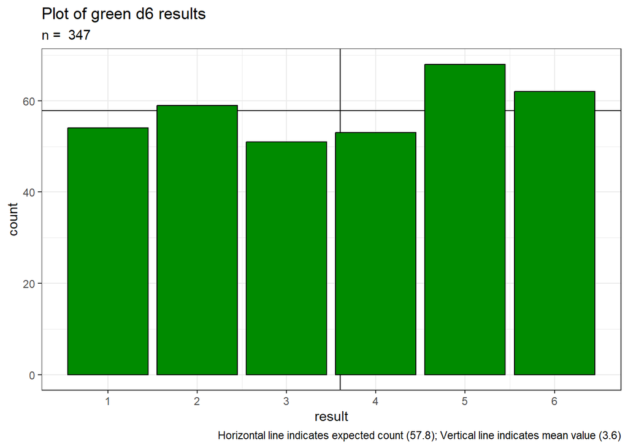

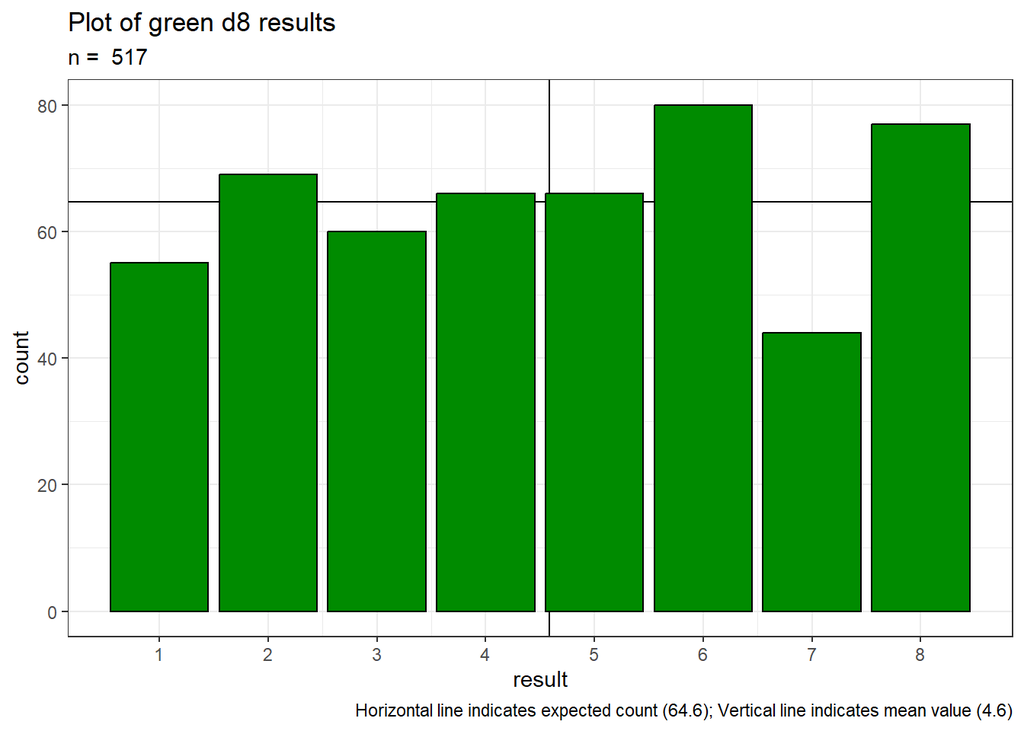

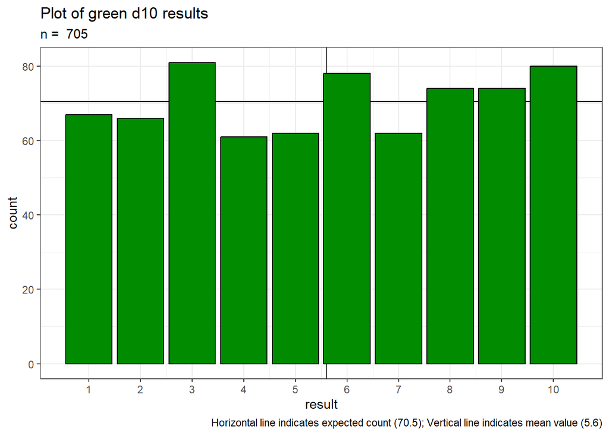

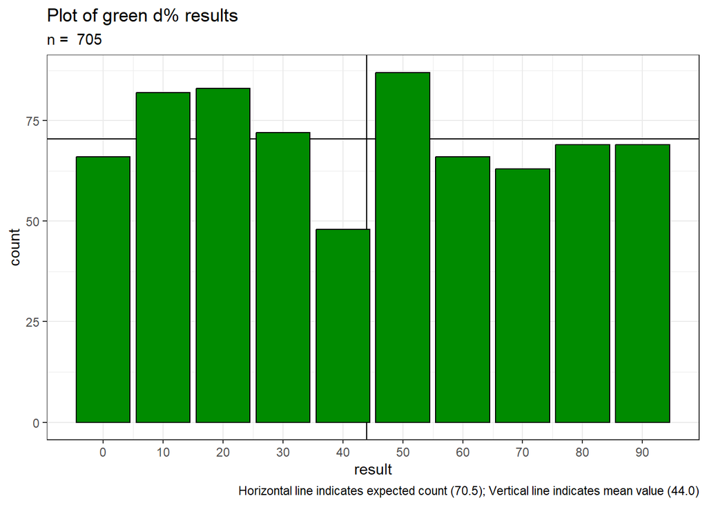

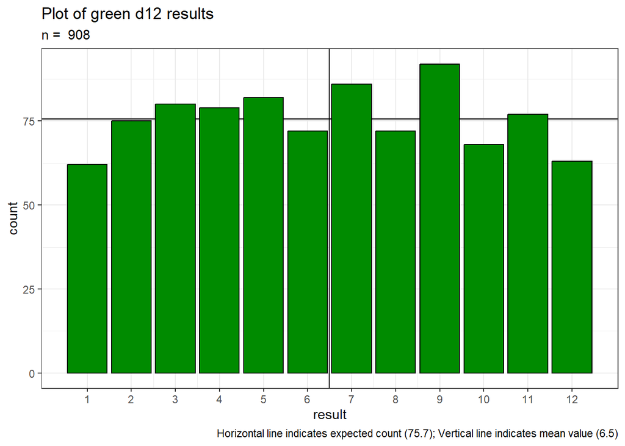

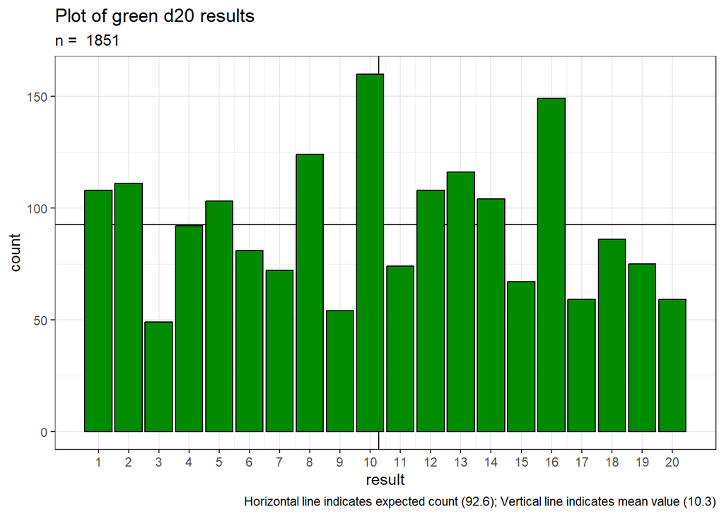

### 5.1.5 Individual d20s

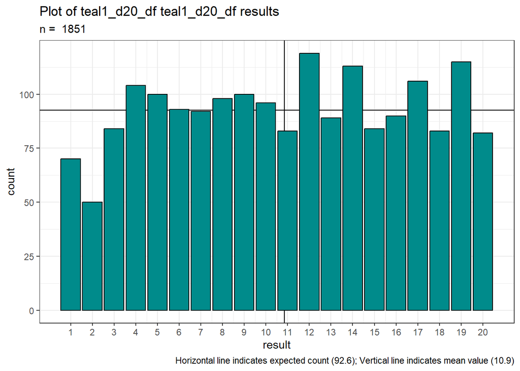

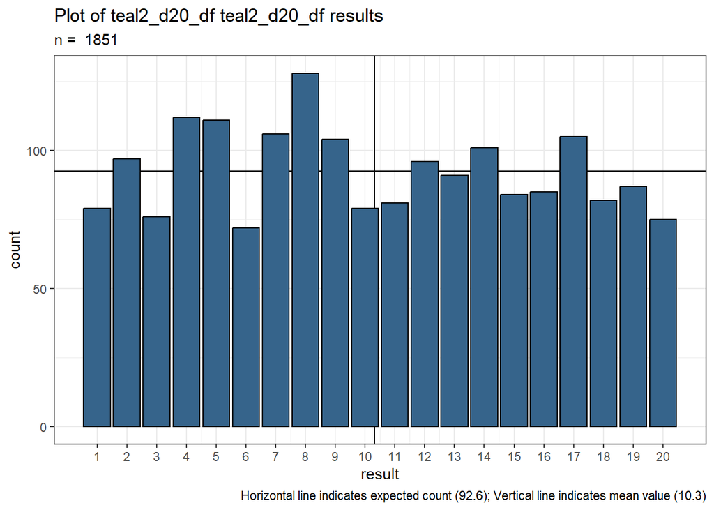

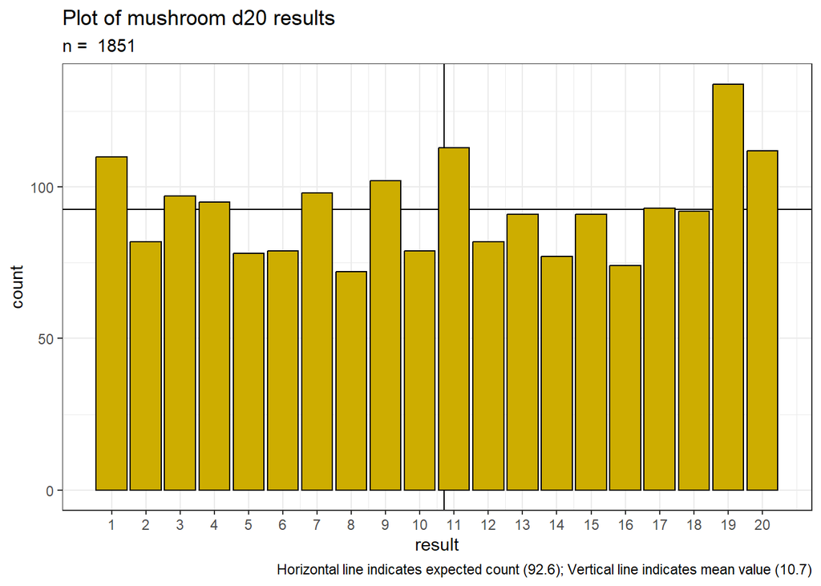